# LanguageIdentifier_2026

### Language Identifier with NLP

Paola Vizcarra

#### Use NLTK to build a model that analyzes sentences in different languages and determines which language is being used.

1. There are 2 input files *data.csv* and *labels.csv* from [source](https://www.kaggle.com/sharansmenon/wili-2018).

WiLI-2018, the Wikipedia language identification benchmark dataset, contains 235000 paragraphs of 235 languages.  
Each language in this dataset contains 1000 rows/paragraphs.

- In the data.csv file there are 235,000 rows (235 unique values) and 2 columns, containing paragraphs in the different languages and the abbreviation identifier for the language used.
- The labels.csv file contains 235 rows/unique values and 9 columns, containing the label/abbreviation, its corresponding language and 7 other identifiers.

#### Tokenizing Asian text

Languages like Chinese and Japanese contains continuous stream of characters with no explicit separators, one way to tokenize and use segmentation in these texts is to use Half-overlapping bi n-grams. In order to preserve some words, it is necessary to overlap symbols to create constructs that will help match the right bi n-grams.  
This estimation shows to be highly effective.  
[source](https://www.youtube.com/watch?v=HYwKGZIvvb4)

1a. Read data from data.csv into a DataFrame.  
Print the size of the DataFrame and the first few lines of data.

```
(235000, 2)
```

|  | text | class |
| --- | --- | --- |
| 0 | Klement Gottwaldi surnukeha palsameeriti ning ... | est\n |
| 1 | Sebes, Joseph; Pereira Thomas (1961) (på eng).... | swe\n |
| 2 | भारतीय स्वातन्त्र्य आन्दोलन राष्ट्रीय एवम क्षे... | mai\n |
| 3 | Après lo cort periòde d'establiment a Basilèa,... | oci\n |
| 4 | ถนนเจริญกรุง (อักษรโรมัน: Thanon Charoen Krung... | tha\n |

1b. Read data from labels.csv into a DataFrame.  
Print the size of the DataFrame and the first few lines of data.

```
(235, 9)
```

|  | Label | English | Wiki Code | ISO 369-3 | German | Language family | Writing system | Remarks | Synonyms |
| --- | --- | --- | --- | --- | --- | --- | --- | --- | --- |
| 0 | ace | Achinese | ace | ace | Achinesisch | Austronesian | NaN | NaN | NaN |
| 1 | afr | Afrikaans | af | afr | Afrikaans | Indo-European | NaN | NaN | NaN |
| 2 | als | Alemannic German | als | gsw | Alemannisch | Indo-European | NaN | (ursprünglich nur Elsässisch) | NaN |
| 3 | amh | Amharic | am | amh | Amharisch | Afro-Asiatic | NaN | NaN | NaN |
| 4 | ang | Old English | ang | ang | Altenglisch | Indo-European | NaN | (ca. 450-1100) | Angelsächsisch |

1c. First clean the label (remove '/n') in the class column in the data DataFrame.  
Then, replace the label for its correspondent language.

```
(235000, 2)
```

|  | text | class |
| --- | --- | --- |
| 0 | Klement Gottwaldi surnukeha palsameeriti ning ... | Estonian |
| 1 | Sebes, Joseph; Pereira Thomas (1961) (på eng).... | Swedish |
| 2 | भारतीय स्वातन्त्र्य आन्दोलन राष्ट्रीय एवम क्षे... | Maithili |
| 3 | Après lo cort periòde d'establiment a Basilèa,... | Occitan |
| 4 | ถนนเจริญกรุง (อักษรโรมัน: Thanon Charoen Krung... | Thai |

1d. List all the languages found in the DataFrame.

```
array(['Estonian', 'Swedish', 'Maithili', 'Occitan', 'Thai', 'Oromo',
       'Limburgan', 'Gujarati', 'Western Panjabi', 'Zeeuws',
       'Karachay-Balkar', 'Haitian Creole', 'Picard', 'Tamil',
       'Vietnamese', 'Panjabi', 'Silesian', 'Central Kurdish', 'Friulian',
       'Wu Chinese', 'Egyptian Arabic', 'Tongan', 'Basque', 'Banyumasan',
       'Gilaki', 'Dutch', 'Tibetan', 'Japanese', 'Aragonese', 'Sardinian',
       'Extremaduran', 'Sinhala', 'Kurdish', 'Chechen', 'Turkmen',
       'Pangasinan', 'Turkish', 'Alemannic German', 'Komi-Permyak',
       'Latin', 'Urdu', 'Tatar', 'Buryat', 'Indonesian', 'Kirghiz',
       'Cantonese', 'Danish', 'Portuguese', 'French', 'Oriya', 'Bokmål',
       'Lojban', 'Konkani', 'Amharic', 'Central Khmer', 'Serbo-Croatian',
       'Slovene', 'Bosnian', 'Tetum', 'Standard Chinese', 'Korean',
       'Yakut', 'Aromanian', 'Asturian', 'Wolof', 'Bulgarian',
       'Scottish Gaelic', 'Malay', 'Crimean Tatar', 'Luganda',
       'Sundanese', 'Breton', 'Mongolian', 'Nepali (macrolanguage)',
       'Igbo', 'Min Dong', 'Assamese', 'Guarani', 'Hindi', 'Marathi',
       'Lingala', 'Interlingue', 'Lombard', 'Burmese', 'Iloko',
       'Kashubian', 'Tuvan', 'Irish', '', 'Jamaican Patois', 'Sicilian',
       'Belarusian (Taraschkewiza)', 'Dimli', 'Cornish', 'Faroese',
       'Malagasy', 'Yiddish', 'Northern Sami', 'Spanish', 'Kabardian',
       'Udmurt', 'Icelandic', 'Ripuarisch', 'Sanskrit', 'Azerbaijani',
       'Neapolitan', 'Lower Sorbian', 'Pampanga', 'Welsh', 'Serbian',
       'Saterfriesisch', 'Telugu', 'Swahili (macrolanguage)', 'Vlaams',
       'Mazanderani', 'Belarusian', 'Ladino', 'Interlingua', 'Avar',
       'Lao', 'Minangkabau', 'Italian', 'West Low German', 'Ossetian',
       'Kabyle', 'Pushto', 'Finnish', 'Sindhi', 'Karakalpak', 'Persian',
       'Chavacano', 'Catalan', 'Classical Nahuatl', 'Eastern Mari',
       'Tarantino dialect', 'Arpitan', 'Romanian', 'Newari', 'Bavarian',
       'Latgalian', 'Võro', 'Latvian', 'Czech', 'Yoruba',
       'Northern Sotho', 'Bashkir', 'Russian', 'Achinese', 'Moksha',
       'Veps', 'Samogitian', 'Uighur', 'Lithuanian', 'Albanian', 'Somali',
       'Slovak', 'Scots', 'Ukrainian', 'Maori', 'Croatian', 'Volapük',
       'English', 'Manx', 'Bengali', 'Ido', 'Javanese', 'Tulu',
       'Western Mari', 'Fiji Hindi', 'Shona', 'Waray', 'Maltese',
       'Emilian', 'Tswana', 'Lezghian', 'Hakka Chinese', 'Komi',
       'South Azerbaijani', 'Quechua', 'Literary Chinese', 'Arabic',
       'Western Frisian', 'Doteli', 'Malayalam', 'Hebrew', 'Gagauz',
       'Chuvash', 'Afrikaans', 'Papiamento', 'Kinyarwanda',
       'Old English ', 'Kazakh', 'Banjar', 'Armenian', 'Livvi-Karelian',
       'Mingrelian', 'Uzbek', 'Central Bikol', 'Pennsylvania German',
       'Upper Sorbian', 'Sranan', 'Georgian', 'Tagalog',
       'Norwegian Nynorsk', 'Galician', 'Romansh', 'Kannada', 'Cherokee',
       'Northern Luri', 'Dhivehi', 'Erzya', 'Corsican', 'Hungarian',
       'Narom', 'Palatine German', 'Walloon', 'Bhojpuri', 'Esperanto',
       'German', 'Navajo', 'Mirandese', 'Polish', 'Rusyn', 'Venetian',
       'Low German', 'Aymara', 'Tajik', 'Cebuano', 'Xhosa', 'Bishnupriya',
       'Modern Greek', 'Ligurian', 'Hausa', 'Macedonian', 'Luxembourgish'],
      dtype=object)
```

1e. Use the DataFrame to develop a Language Identifier for 25 different languages.  
Select the languages to be used on the Language Identifier.

```
25
```

1f. Using the selected languages, filter the DataFrame.

```
(25000, 2)
```

|  | text | class |
| --- | --- | --- |
| 0 | Klement Gottwaldi surnukeha palsameeriti ning ... | Estonian |
| 1 | Sebes, Joseph; Pereira Thomas (1961) (på eng).... | Swedish |
| 2 | ถนนเจริญกรุง (อักษรโรมัน: Thanon Charoen Krung... | Thai |
| 3 | Bùi Tiến Dũng (sinh năm 1959 tại huyện Ứng Hòa... | Vietnamese |
| 4 | De spons behoort tot het geslacht Haliclona en... | Dutch |
| 5 | エノが行きがかりでバスに乗ってしまい、気分が悪くなった際に助けるが、今すぐバスを降りたいと運... | Japanese |

1g. Rename languages as needed, keep one word ('Standard Chinese' becomes 'Chinese').

|  | text | class |
| --- | --- | --- |
| 17440 | В 1754 г. Ломоносов, недовольный тем, что прем... | Russian |
| 7445 | Im ausgehenden 16. Jahrhundert war das Stift P... | German |
| 6396 | When Goodrem was 15 years old, her first manag... | English |
| 13764 | 13 जनवरी- अमेरिकी समाचार पत्र न्यूयार्क टाइम्स... | Hindi |
| 7104 | Există mai mult de 100 de manuscrise dintr-o l... | Romanian |

1i. Create the y variable from the DataFrame.  
Print the size of y.

```
(25000,)
```

```
0      Estonian
1       Swedish
2          Thai
3    Vietnamese
4         Dutch
Name: class, dtype: object
```

1j. Create the X variable from the DataFrame.  
Print the size of X and the first few lines of x.

```
(25000, 1)
```

|  | text |
| --- | --- |
| 0 | Klement Gottwaldi surnukeha palsameeriti ning ... |
| 1 | Sebes, Joseph; Pereira Thomas (1961) (på eng).... |
| 2 | ถนนเจริญกรุง (อักษรโรมัน: Thanon Charoen Krung... |
| 3 | Bùi Tiến Dũng (sinh năm 1959 tại huyện Ứng Hòa... |
| 4 | De spons behoort tot het geslacht Haliclona en... |

1k. Find the indexes of Chinese and Japanese sentences in the DataFrame.  
Print the first indexes on each.

```
[12, 120, 131, 164, 262]
[5, 8, 34, 47, 86]
```

1l. Continue the pre-processing step by:

- remove all numbers and underscores  
  (every language has its own characters so we won't just keep a to Z)
- lowercase all words

Modify the segmentation for Chinese and Japanese.  
Print the resulting X variable.

```
                                                   0
0  klement gottwaldi surnukeha palsameeriti ning ...
1  sebes, joseph; pereira thomas    på eng . the ...
2  ถนนเจริญกรุง  อักษรโรมัน: thanon charoen krung...
3  bùi tiến dũng  sinh năm   tại huyện ứng hòa tỉ...
4  de spons behoort tot het geslacht haliclona en...
5  エノ ノが が行 行き きが がか かり りで でバ バス スに に乗 乗っ って てし し...
(25000, 1)
```

1m. Convert the strings in X to vectors of numbers.  
Show the size of the vectors.

[output not shown]

```
(25000, 400691)
```

1n. Split the dataset into training and testing sets.  
Show the size of the sets.

```
(17500, 400691) (17500,) (7500, 400691) (7500,)
```

1o. Use the Multinomial Naive Bayes model to train, then test the model.

```
array(['Korean', 'Dutch', 'Hebrew', ..., 'Korean', 'Polish', 'Korean'],
      dtype='<U10')
```

1p. Show the accuracy of the model by displaying the accuracy score, confusion matrix, and F1 score.

[output not shown]

[figure not shown]

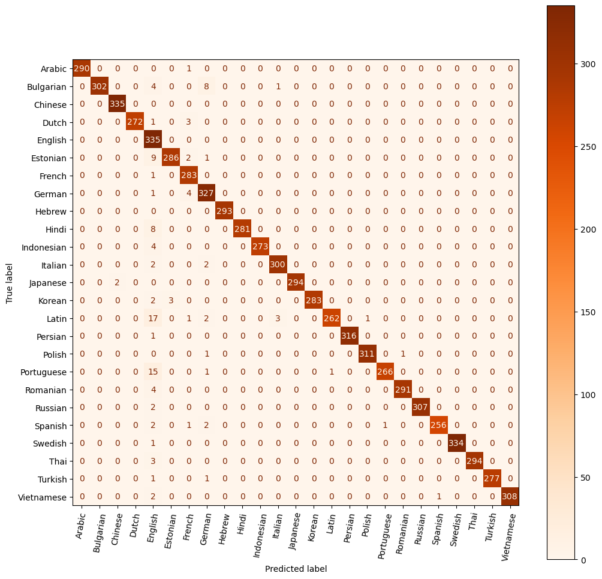

Both, the confusion matrix and F1 score per language show Chinese and Japanese predictions are highly assertive.  
Overall, predictions are balanced.

1q. Testing other sentences.

```
array(['Spanish', 'French', 'English', 'Chinese', 'Japanese', 'Turkish',
       'Arabic', 'Swedish'], dtype='<U10')
```

Percentage of accurate predictions is high.

1r. Let user enter a text string and have the model predict the language.

```
Test the Language Identifier,
Enter some text and then "Press Enter" to see the result.
```

```
You entered: 春になると、色とりどりの花が静かに咲き始めます。
Language identified as: Japanese
```

### Output and conclusion

In order to build a highly effective Language Identifier, languages have to be tokenized according to their writing system (Some writing systems don't use spaces or use spaces between syllables instead of between words, others use suffixes in a complete different way than English does).  
Some methods, like Half-overlapping bi n-grams show to be very effective for languages like Chinese and Japanese. But, the more diverse the languages in the identifier, the greater the need for a custom tokenizer and steammer for each language. Different languages need different approaches.